# Chi-square

Oct. 1

# The Chi-square Test

## Bridge In

## Learning Outcomes

Upon completing this module, students will be able to:

- Conduct $\chi^2$ tests in R.
- Create appropriate data visualizations for comparisons of categorical data.
- Report results of $\chi^2$ tests in APA style.
- Accurately interpret the results of $\chi^2$ tests.
- Evaluate the strength of evidence provided by $\chi^2$ tests in studies using $\chi^2$ tests of independence for categorical data.

# The Study: Reminders Through Association

## Summary

Someone briefly remind us of the design of the study (focus on study 5).

## What We’re Reproducing

Results from two $\chi^2$ tests from study 5.

### We’ll Do Together

“…participants are more likely to follow through when they are assigned a cue-based reminder (in the forced-reminder through-association condition, 87%) than when no cue-based reminder is available (none condition, 59%), $\chi^2$(1, *N* = 305) = 30.22, *p* < .001.”

### On Your Own

“…those in the costly-reminder-through-association condition were not only more likely to earn the bonus (74%) than those in the none condition (59%), $\chi^2$(1, *N* = 297) = 7.23, *p* = .007,…”

# Let’s Get Started

## tRy it! Setup

Complete the steps in the “Setup” portion of the lab activity.

1. Download “RTA_study5.csv” and “codebook database.xlsx” from Canvas.
2. Import “RTA_study5.csv” to R.
3. Convert the following variables to factors, `condition`, `choice`, and `correct`. Read from “codebook database.xlsx” to identify appropriate factor labels.

## Import the Data

Import “RTA_study5.csv” to R.

```r
dta <- read.csv("data/RTA_study5.csv")
```

## Convert Variables to Factors

Convert the following variables to factors, `condition`, `choice`, and `correct`. Read from “codebook database.xlsx” to identify appropriate factor labels.

## Convert `condition` to Factor

The codebook tells us the levels/labels for condition.

```r
dta$condition <- factor(dta$condition,
  levels = 1:4,
  labels = c("Free", "None", "Costly", "All")
)
```

```
##  [1] Free   Costly Costly None   Free   Free   All    All    None   All
## Levels: Free None Costly All
```

## Convert `choice` to Factor

What does `choice` tell us?

```r
dta$choice <- factor(dta$choice,
  levels = c(0, 1),
  labels = c("did not take reminder", "took reminder")
)
```

```
##  [1] took reminder         took reminder         did not take reminder
##  [4] did not take reminder did not take reminder did not take reminder
##  [7] did not take reminder did not take reminder did not take reminder
## [10] took reminder
## Levels: did not take reminder took reminder
```

## Convert `correct` to Factor

What does `correct` tell us?

```r
dta$correct <- factor(dta$correct,
  levels = c(0, 1),
  labels = c("incorrect", "correct")
)
```

```
##  [1] correct   incorrect incorrect correct   correct   correct   incorrect
##  [8] correct   correct   correct
## Levels: incorrect correct
```

# Reproduce Results

## Result 1

> “…participants are more likely to follow through when they are assigned a cue-based reminder (in the forced-reminder through-association condition, 87%) than when no cue-based reminder is available (none condition, 59%), $\chi^2$(1, *N* = 305) = 30.22, *p* < .001.”

## tRy it! Subset & Drop Levels

1. Create a subset of your `data.frame` that includes only the relevant levels of `condition`.
2. Use `droplevels()` to drop the extra levels of `condition`.

*Hint:* You can use either `|` or `%in%` to subset with one line of code. Otherwise, you could do it in two steps.

## Subset

### Option 1: Multiple Steps

```r
dta1 <- dta
dta1 <- subset(dta1, condition != "Free")
dta1 <- subset(dta1, condition != "Costly")
```

## Subset (2)

### Option 2: Using `|`

Remember that `|` means “or”.

```r
dta1 <- subset(dta, condition == "All" | condition == "None")
```

Can you imagine a situation where this approach might be unwieldy?

## Subset (3)

### Option 3: Using `%in%`

```r
dta1 <- subset(dta, condition %in% c("All", "None"))
```

## Check Your Work (an aside)

Why should you check your work as you go?

- Just because R didn’t return an error, doesn’t mean your code did what you wanted.
- Sometimes errors later in the code are the result of an unrecognized mistake earlier.
- Code that does the wrong thing but doesn’t return an error is harder to catch.
- It saves time “debugging” down the line.

## Did Our Subsetting Work?

*We don’t need to see this in your code*

We can check with the function `all()`, which returns:

- TRUE if all values in the vector are TRUE.
- FALSE if any values in the vector are FALSE.
- NA otherwise.

## Did Our Subsetting Work? (2)

```r
all(dta1$condition %in% c("All", "None"))
```

```
## [1] TRUE
```

`all()` can be a useful tool for testing your code.

## Did Our Subsetting Work? (3)

Alternatively, we can use `summary()`, which will count the number of times each factor level occurs.

```r
summary(dta1$condition)
```

```
##   Free   None Costly    All
##      0    153      0    152
```

## Drop Extra Levels

Why do we need to do this?

```r
levels(dta1$condition)
```

```
## [1] "Free"   "None"   "Costly" "All"
```

## Drop Extra Levels (2)

```r
dta1$condition <- droplevels(dta1$condition)
```

```r
levels(dta1$condition)
```

```
## [1] "None" "All"
```

# Mosaic Plots

## A Mosaic Plot

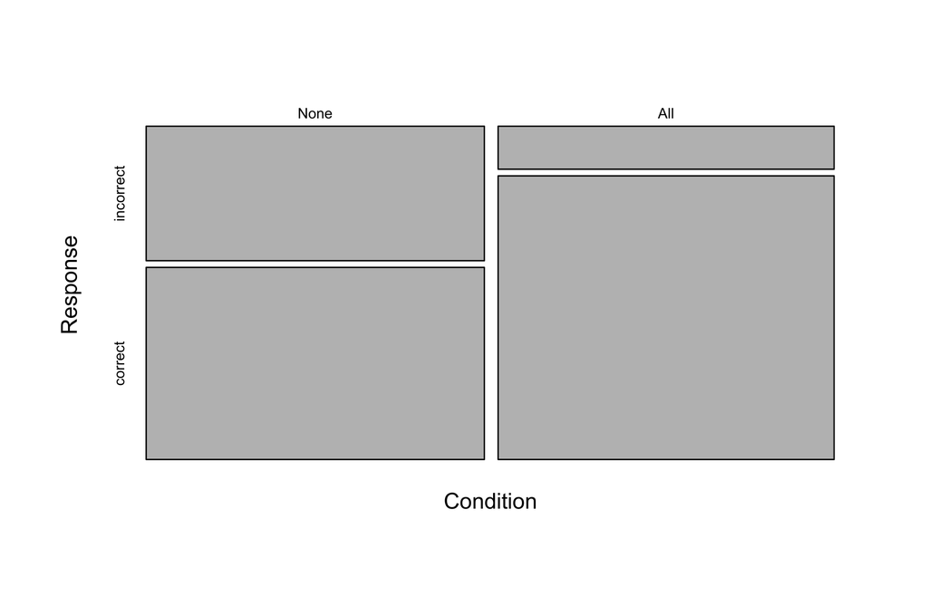

## tRy it! Make a Mosiac Plot

1. Read the documentation for `mosaicplot()`. Which argument(s) is/are required for the default S3 method?
2. Create a contingency table using the function recommended in the `mosaicplot()` documentation.
3. Make a mosaic plot.
4. Remove the main title.
5. Give appropriate labels to the x and y axes.

## Making a Mosaic Plot

- How many required arguments for `mosaicplot()`? How do you know?
- What is the required argument?
- What value does it expect?

## Contingency Table First

```r
cont_table <- table(dta1$condition, dta1$correct)
```

```r
cont_table <- table(Condition = dta1$condition, Response = dta1$correct)
```

## Now Make the Plot

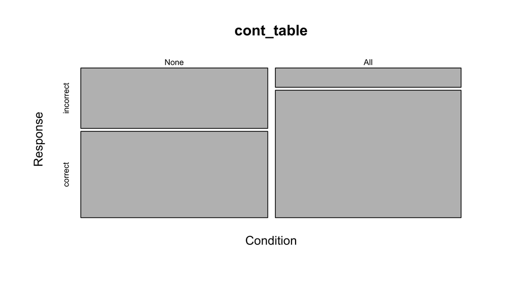

```r
mosaicplot(cont_table)
```

## Change the Labels

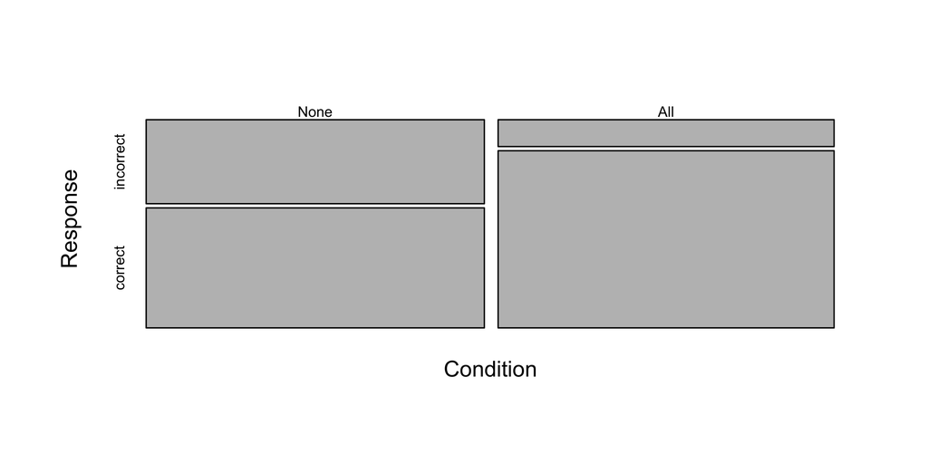

```r
mosaicplot(table(dta1$condition, dta1$correct),
  main = NA,
  xlab = "Condition",
  ylab = "Response"
)
```

# Bar Plot Using `ggplot2`

## A `ggplot2` Bar Plot

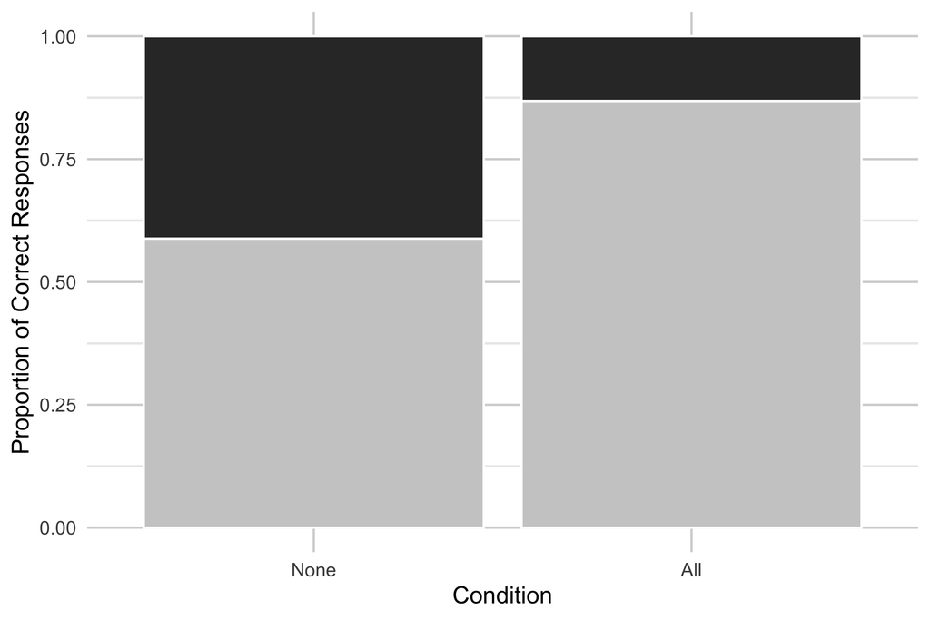

## The Basics

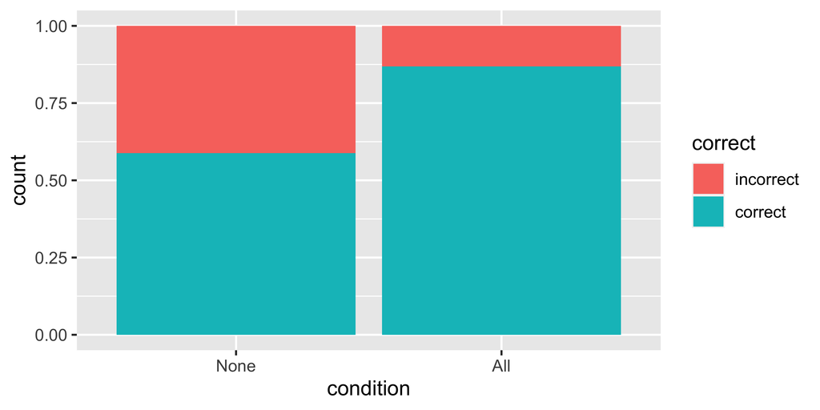

```r
ggplot(dta1, aes(x = condition, fill = correct)) +
  geom_bar(position = "fill")
```

# The Percentages

## What Percentages?

> “…participants are more likely to follow through when they are assigned a cue-based reminder (in the forced-reminder through-association condition, **87%**) than when no cue-based reminder is available (none condition, **59%**), $\chi^2$(1, *N* = 305) = 30.22, *p* < .001.”

How do we interpret these percentages?

## Calculating These Percentages

Several ways to do this. E.g., using the contingency table.

```
##          Response
## Condition incorrect correct
##      None        63      90
##      All         20     132
```

```r
cont_table / rowSums(cont_table)
```

```
##          Response
## Condition incorrect   correct
##      None 0.4117647 0.5882353
##      All  0.1315789 0.8684211
```

## Using Subsets

- Recall that FALSE = 0, and TRUE = 1.
- Therefore, the mean of a logical vector is the proportion of TRUE values.
- For example:

```r
mean(c(TRUE, TRUE, TRUE, FALSE))
```

```
## [1] 0.75
```

```r
mean(c(1, 1, 1, 0))
```

```
## [1] 0.75
```

## Using Subsets (2)

```r
mean(dta1$correct[dta1$condition == "All"] == "correct")
```

```
## [1] 0.8684211
```

```r
mean(dta1$correct[dta1$condition == "None"] == "correct")
```

```
## [1] 0.5882353
```

## Using Subsets (3)

With `tapply()`

```r
tapply(dta1$correct == "correct", dta1$condition, mean)
```

```
##      None       All
## 0.5882353 0.8684211
```

# Actually Doing a Chi-square Test

## tRy it! Chi-square Test

Use `chisq.test()` to conduct a $\chi^2$ test to compare the groups.

- Consult the documentation for `chisq.test()` to learn how this is done.
- By default, `chisq.test()` applies a continuity correction for 2x2 tables. The authors of the paper do not apply this correction, so you will need to change the default argument to reproduce their results.

## Chi-square Test

Two ways of doing this that are equivalent.

### Option 1

```r
result1 <- chisq.test(x = cont_table, correct = FALSE)
```

### Option 2

```r
result1 <- chisq.test(x = dta1$condition,
  y = dta1$correct,
  correct = FALSE
)
```

## Results of the Chi-square

### Test Statistic

```r
result1
```

```
##
##  Pearson's Chi-squared test
##
## data:  dta1$condition and dta1$correct
## X-squared = 30.22, df = 1, p-value = 3.857e-08
```

### *N*

```r
sum(cont_table)
```

```
## [1] 305
```

## The Chi-square Distribution

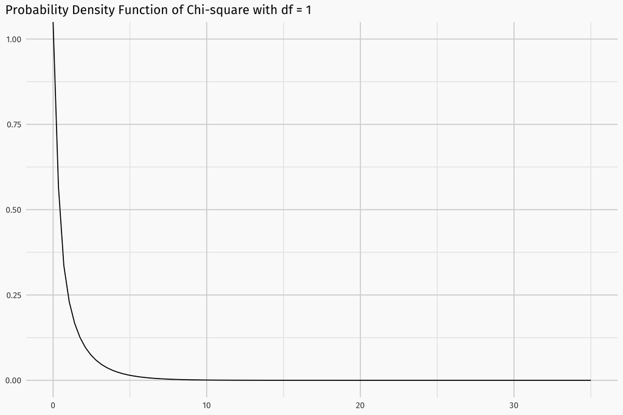

# Assumptions of Chi-square

## What Are the Assumptions?

Basically two main assumptions:

1. Expected frequencies are sufficiently large.
2. Observations are independent.

## Expected Frequencies

Expected frequencies of at least 80% of cells should be greater than 5.

```r
result1$expected
```

```
##               dta1$correct
## dta1$condition incorrect  correct
##           None  41.63607 111.3639
##           All   41.36393 110.6361
```

## Expected Frequencies too Small?

- Fisher’s exact test computes exact *p* values.
- Does not use expected frequencies to compute *p*.
- Generally preferred over chi-square test (especially for small samples).

## tRy it! Fisher’s Exact Test

Use `fisher.test()` to compare the groups using Fisher’s exact test.

## Fisher’s Exact Test

```r
fisher.test(x = cont_table)
```

```
##
##  Fisher's Exact Test for Count Data
##
## data:  cont_table
## p-value = 3.919e-08
## alternative hypothesis: true odds ratio is not equal to 1
## 95 percent confidence interval:
##  2.537016 8.614158
## sample estimates:
## odds ratio
##   4.596306
```

## Odds Ratio

Effect size.

- OR = 1 Exposure unrelated to odds of outcome.
- OR > 1 Exposure associated with higher odds of outcome.
- OR < 1 Exposure associated with lower odds of outcome.

## Odds Ratio For This

- OR = 1 Participants in all condition were no more likely to get it correct.
- OR > 1 Participants in all condition more likely to get it correct.
- OR < 1 Participants in all condition less likely to get it correct.